# Seminário Modelos

Catarina, Isabella, Júlia, Lucas e Tiago

```r
library(tidyverse)
library(ggplot2)
library(pastecs)
library(gridExtra)
library(knitr)
library(tidyr)
library(dplyr)
library(qqplotr)
library(lmtest)
library(ggfortify)
library(GGally)
library(car)
library(corrplot)
library(kableExtra)
```

## Banco de dados

O link para o banco de dados escolhido pode ser acessado [aqui](https://www.kaggle.com/datasets/unsdsn/world-happiness?select=2019.csv).

## Objetivo

O trabalho tem como objetivo prever a pontuação de felicidade (Score) de diferentes países com base em variáveis socioeconômicas e ambientais, como PIB per capita, suporte social, expectativa de vida, liberdade para tomar decisões, generosidade e percepção de corrupção e assim, verificar quais características contribuem para um país mais feliz.

## Especificação da base de dados:

O banco de dados “The World Happiness Report” apresenta o ranking dos países mais felizes em 2019 de acordo com vários critérios, os quais são o PIB per capta, apoio social, expectativa de vida, liberdade para fazer escolhas, generosidade e percepção de corrupção. Como objetivo, esse banco quer mostrar tanto o que falta para os países serem mais felizes, quanto ajudar os governos a identificar onde necessita-se mais investimento.

Especificação da Base de Dados

| Coluna | Descrição |
| --- | --- |
| Overall rank | Ranking geral do país. |
| Country or region | Nome do país ou região. |
| Score | Pontuação geral de felicidade (variável dependente). |
| GDP per capita | PIB per capita. |
| Social support | Suporte social. |
| Healthy life expectancy | Expectativa de vida. |
| Freedom to make life choices | Liberdade para tomar decisões na vida. |
| Generosity | Generosidade. |
| Perceptions of corruption | Percepção de corrupção. |

## Determinação das variáveis explicativas e resposta:

### Variável Resposta (Dependente)

- **Score**: Pontuação geral de felicidade, que será prevista pelo modelo.

### Variáveis Explicativas (Independentes)

- **GDP.per.capita**: Representa a prosperidade econômica de um país.
- **Social.support**: Mede o suporte social disponível.
- **Healthy.life.expectancy**: Reflete a saúde da população.
- **Freedom.to.make.life.choices**: Captura a liberdade percebida nas decisões pessoais.
- **Generosity**: Indica a disposição para ajudar os outros.
- **Perceptions.of.corruption**: Mede a percepção de corrupção no governo e nos negócios

## Análise Descritiva

### Score

```
##    Min. 1st Qu.  Median    Mean 3rd Qu.    Max.
##   2.853   4.545   5.380   5.407   6.184   7.769
```

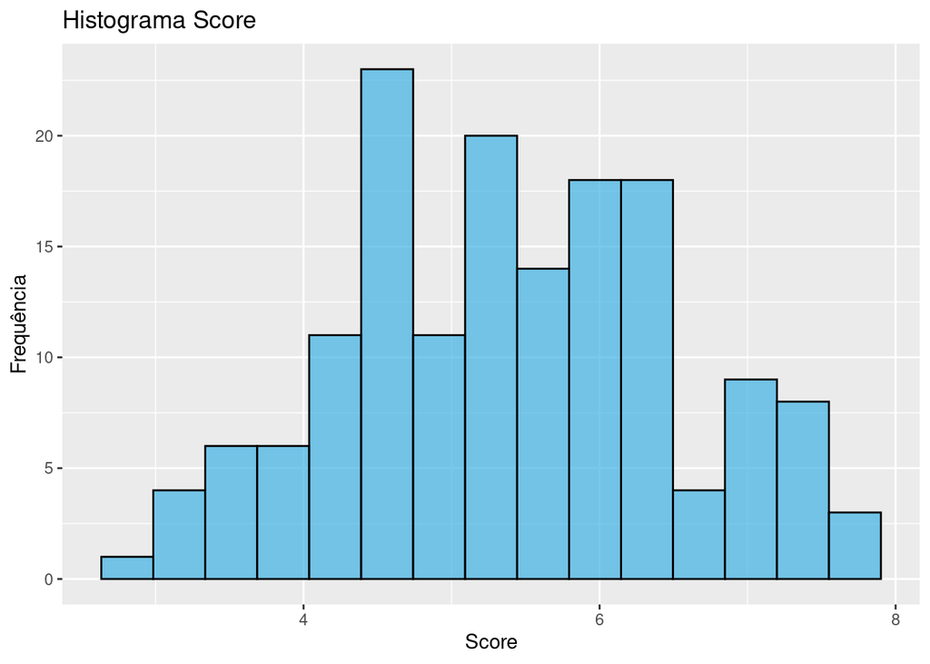

### PIB per capita

```
##    Min. 1st Qu.  Median    Mean 3rd Qu.    Max.
##  0.0000  0.6028  0.9600  0.9051  1.2325  1.6840
```

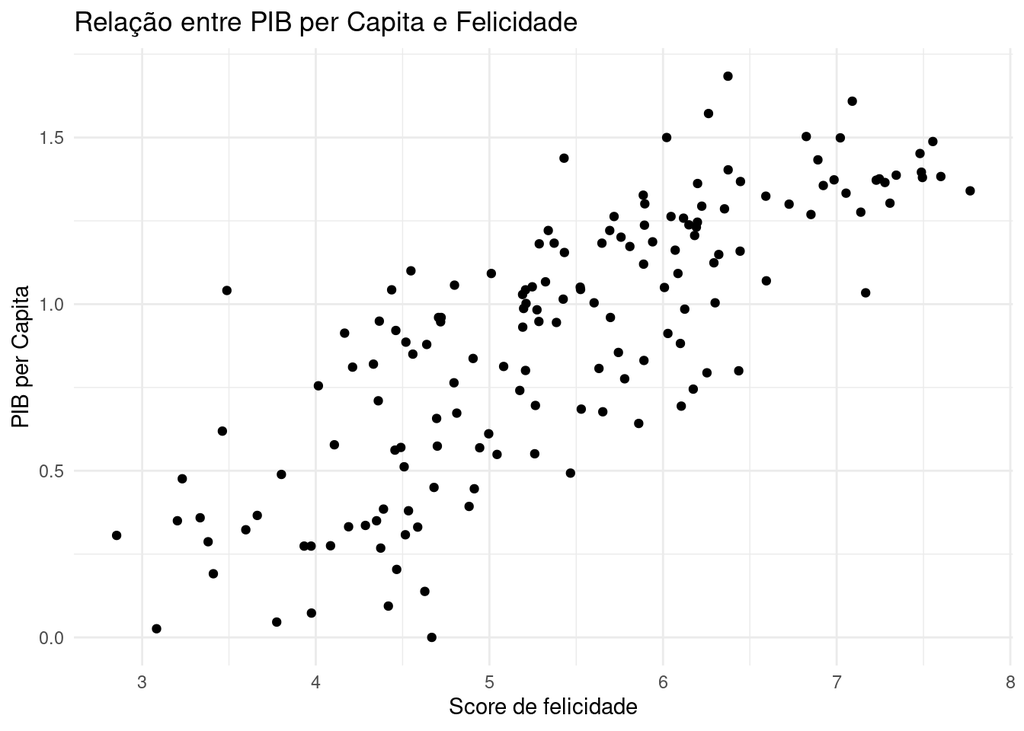

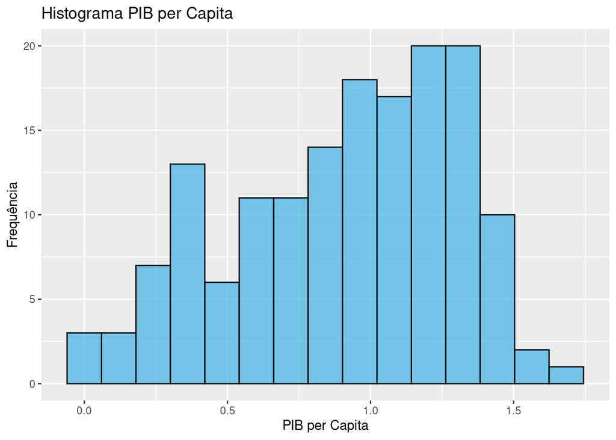

```
## O país com o maior PIB per capita é: Qatar - PIB per capita: 1.684
```

```
## O país com o menor PIB per capita é: Somalia - PIB per capita: 0
```

### Suporte social

```
##    Min. 1st Qu.  Median    Mean 3rd Qu.    Max.
##   0.000   1.056   1.272   1.209   1.452   1.624
```

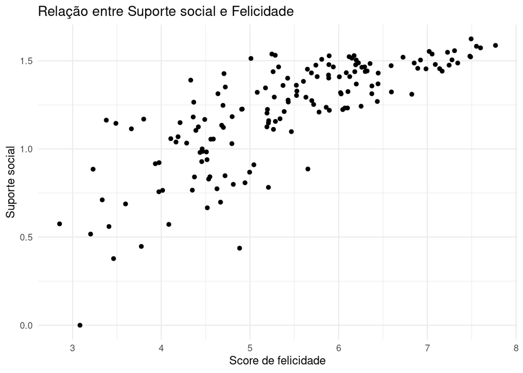

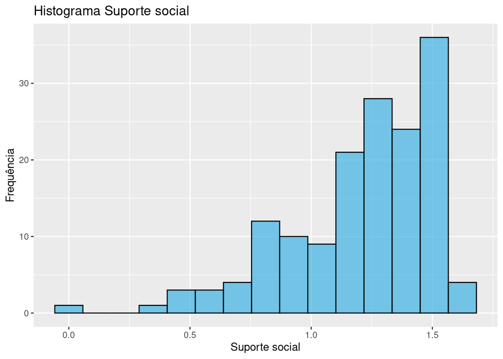

```
## O país com o maior suporte social é: Iceland - Suporte social 1.624
```

```
## O país com o menor suporte social é: Central African Republic - Suporte social: 0
```

### Expectativa de vida

```
##    Min. 1st Qu.  Median    Mean 3rd Qu.    Max.
##  0.0000  0.5477  0.7890  0.7252  0.8818  1.1410
```

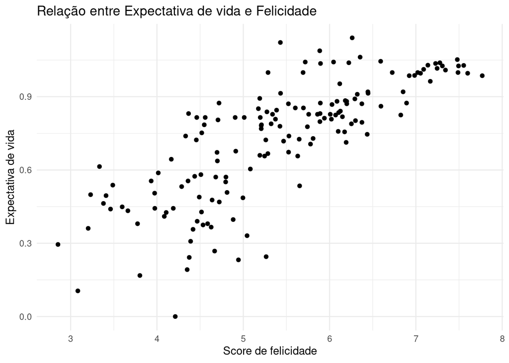

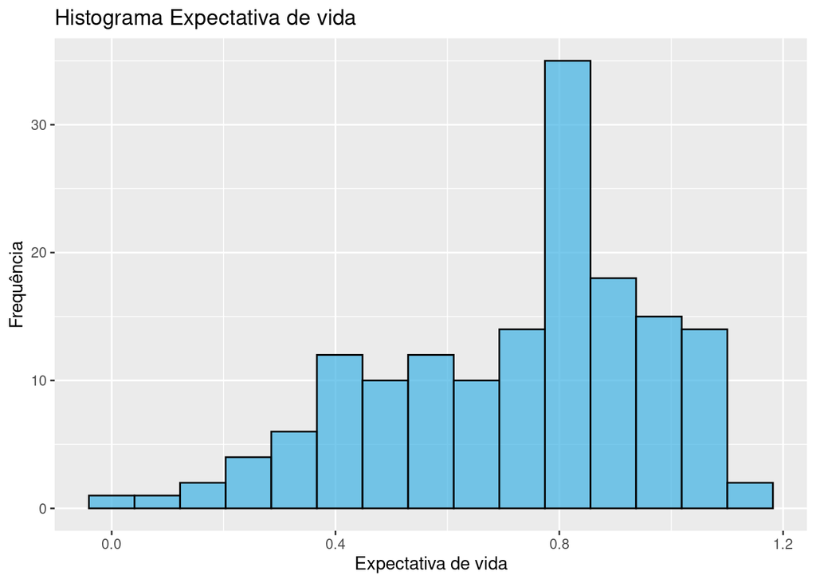

```
## O país com o maior expectativa de vida é: Singapore - Expectativa de vida: 1.141
```

```
## O país com o menor expectativa de vida é: Swaziland - Expectativa de vida: 0
```

### Liberdade para fazer escolhas

```
##    Min. 1st Qu.  Median    Mean 3rd Qu.    Max.
##  0.0000  0.3080  0.4170  0.3926  0.5072  0.6310
```

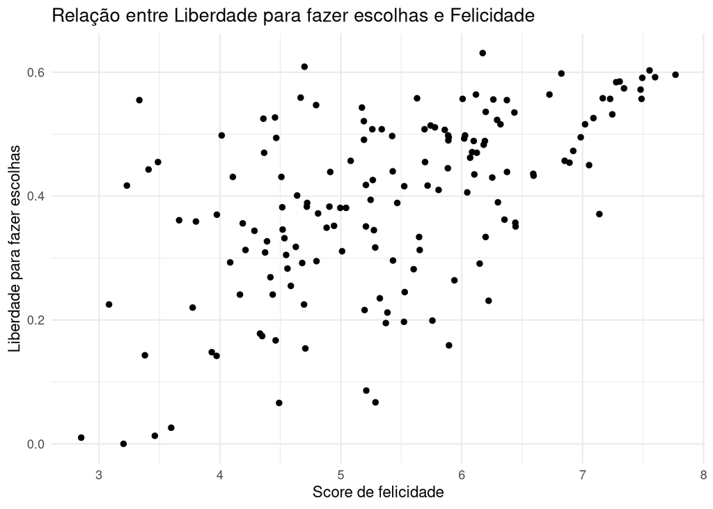

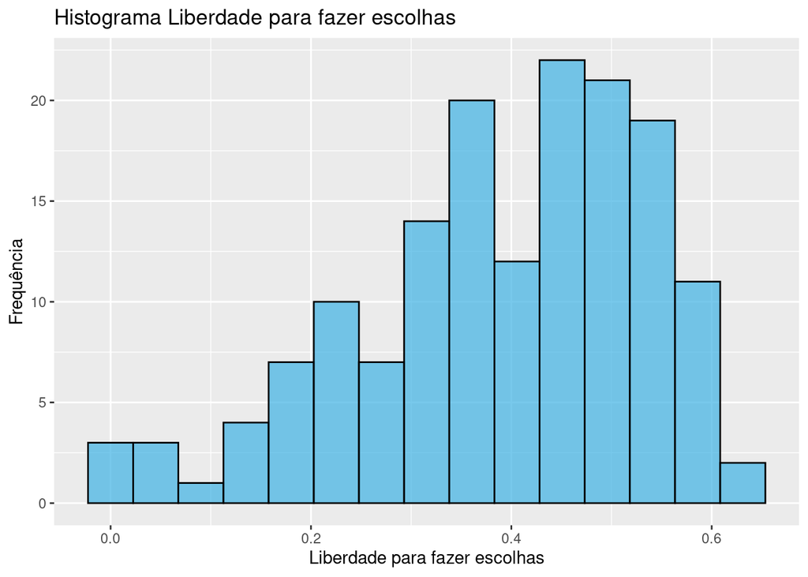

```
## O país com o maior liberdade para fazer escolhas é: Uzbekistan - Liberdade para fazer escolhas: 0.631
```

```
## O país com o menor liberdade para fazer escolhas é: Afghanistan - Liberdade para fazer escolhas: 0
```

### Generosidade

```
##    Min. 1st Qu.  Median    Mean 3rd Qu.    Max.
##  0.0000  0.1087  0.1775  0.1848  0.2482  0.5660
```

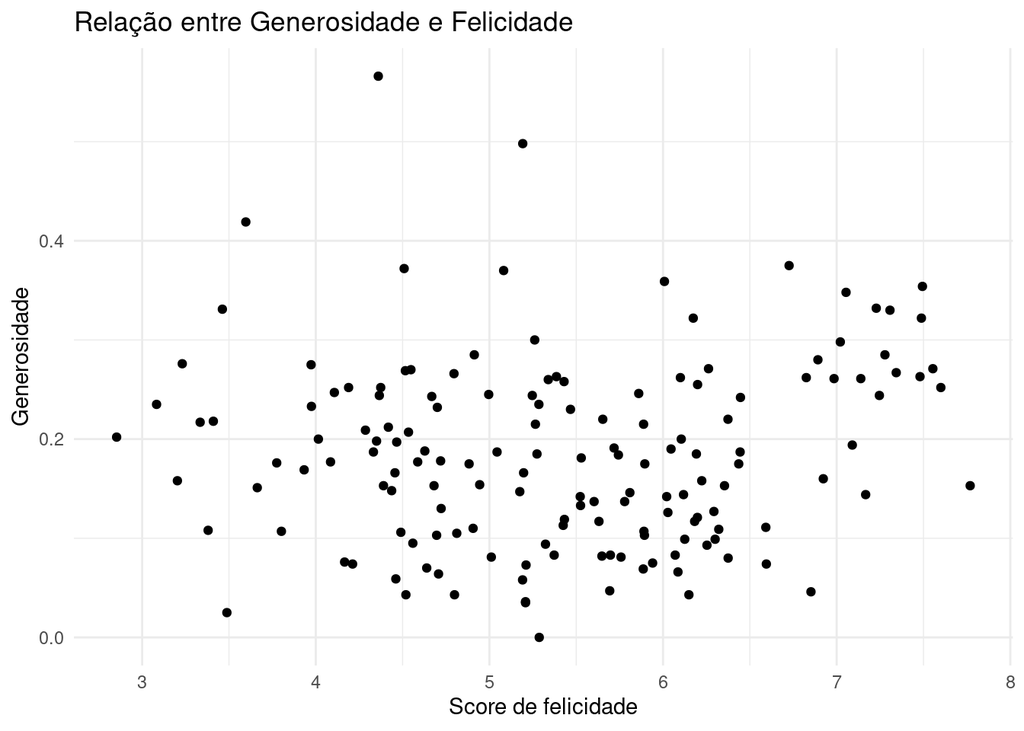

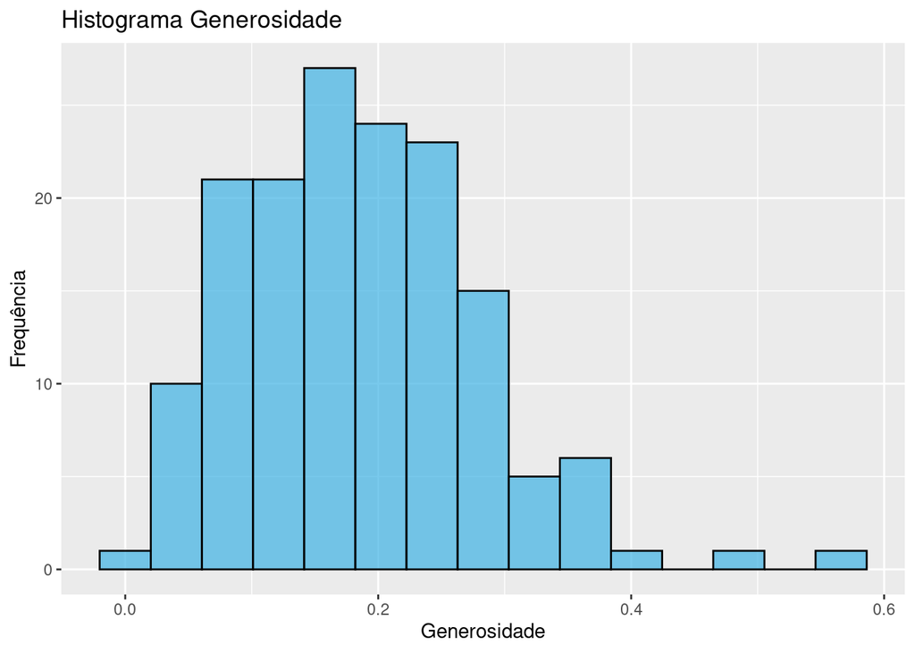

```
## O país com o maior generosidade é: Myanmar - Generosidade: 0.566
```

```
## O país com o menor generosidade é: Greece - Generosidade: 0
```

### Percepção de corrupção

```
##    Min. 1st Qu.  Median    Mean 3rd Qu.    Max.
##  0.0000  0.0470  0.0855  0.1106  0.1412  0.4530
```

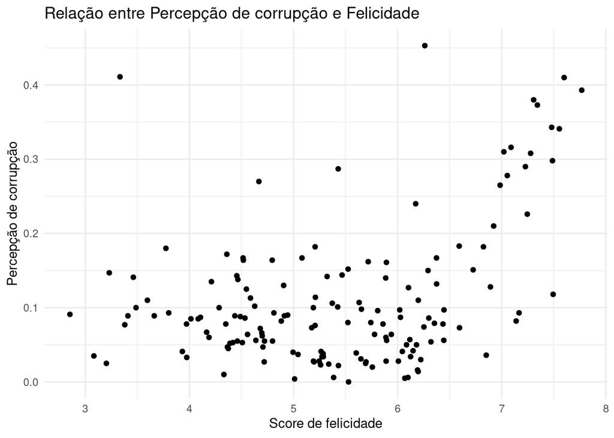

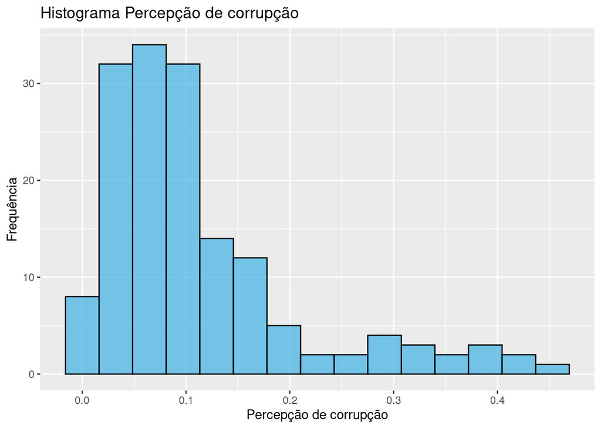

```
## O país com o maior percepção de corrupção é: Singapore - Percepção de corrupção: 0.453
```

```
## O país com o menor percepção de corrupção é: Moldova - Percepção de corrupção: 0
```

## Modelo

```r
# Troca do nome do banco de dados para separar a parte descritiva do modelo

data <- read.csv("2019.csv", header = TRUE, sep = ",", stringsAsFactors = FALSE)
colnames(data) <- make.names(colnames(data))
modelo <- lm(Score ~ GDP.per.capita + Social.support + Healthy.life.expectancy +
               Freedom.to.make.life.choices + Generosity + Perceptions.of.corruption,
             data = data)

summary(modelo)
```

```
##
## Call:
## lm(formula = Score ~ GDP.per.capita + Social.support + Healthy.life.expectancy +
##     Freedom.to.make.life.choices + Generosity + Perceptions.of.corruption,
##     data = data)
##
## Residuals:
##      Min       1Q   Median       3Q      Max
## -1.75304 -0.35306  0.05703  0.36695  1.19059
##
## Coefficients:
##                              Estimate Std. Error t value Pr(>|t|)
## (Intercept)                    1.7952     0.2111   8.505 1.77e-14 ***
## GDP.per.capita                 0.7754     0.2182   3.553 0.000510 ***
## Social.support                 1.1242     0.2369   4.745 4.83e-06 ***
## Healthy.life.expectancy        1.0781     0.3345   3.223 0.001560 **
## Freedom.to.make.life.choices   1.4548     0.3753   3.876 0.000159 ***
## Generosity                     0.4898     0.4977   0.984 0.326709
## Perceptions.of.corruption      0.9723     0.5424   1.793 0.075053 .
## ---
## Signif. codes:  0 '***' 0.001 '**' 0.01 '*' 0.05 '.' 0.1 ' ' 1
##
## Residual standard error: 0.5335 on 149 degrees of freedom
## Multiple R-squared:  0.7792, Adjusted R-squared:  0.7703
## F-statistic: 87.62 on 6 and 149 DF,  p-value: < 2.2e-16
```

## Retas de regressão individuais

**- Relação individual das variáveis explicativas(GDP per capIta, Social support, Healthy life expectancy, Freedom to make life choices, Generosity e Perceptions of corruption) com a variável resposta(Score)**

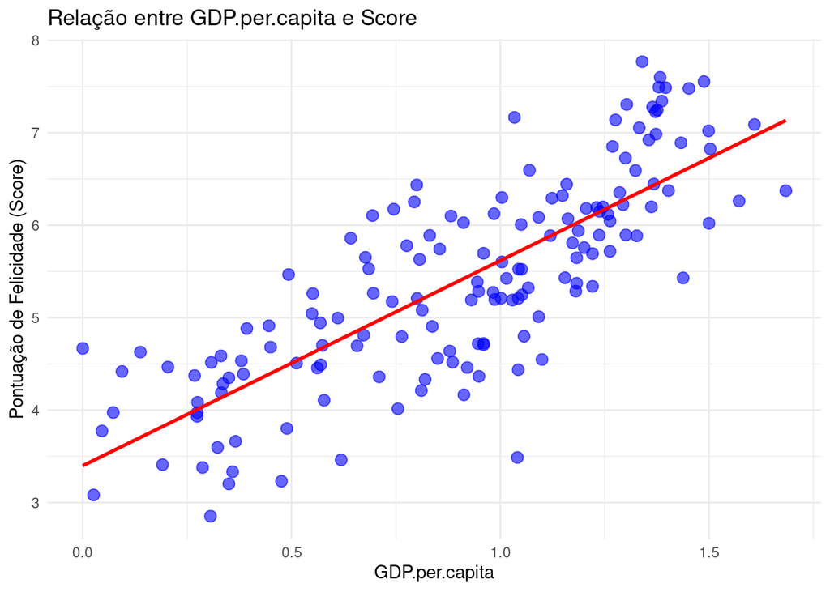

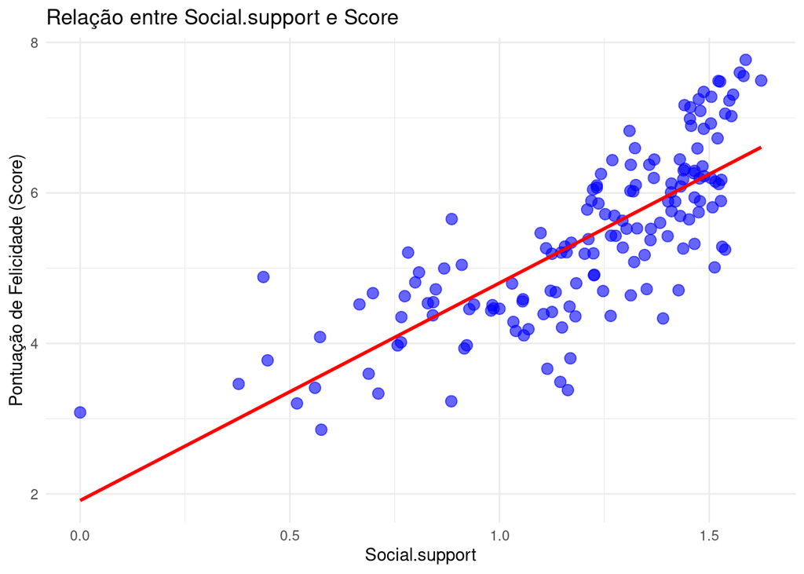

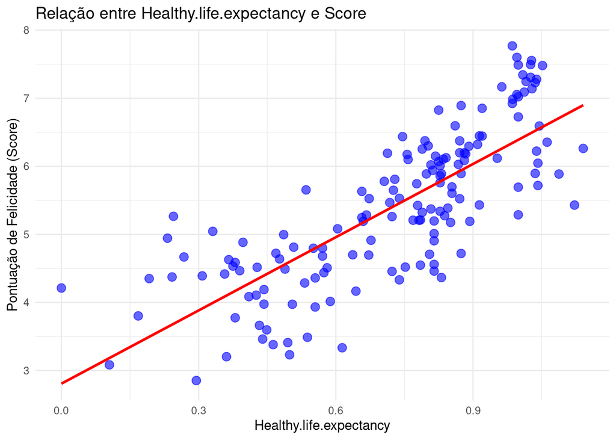

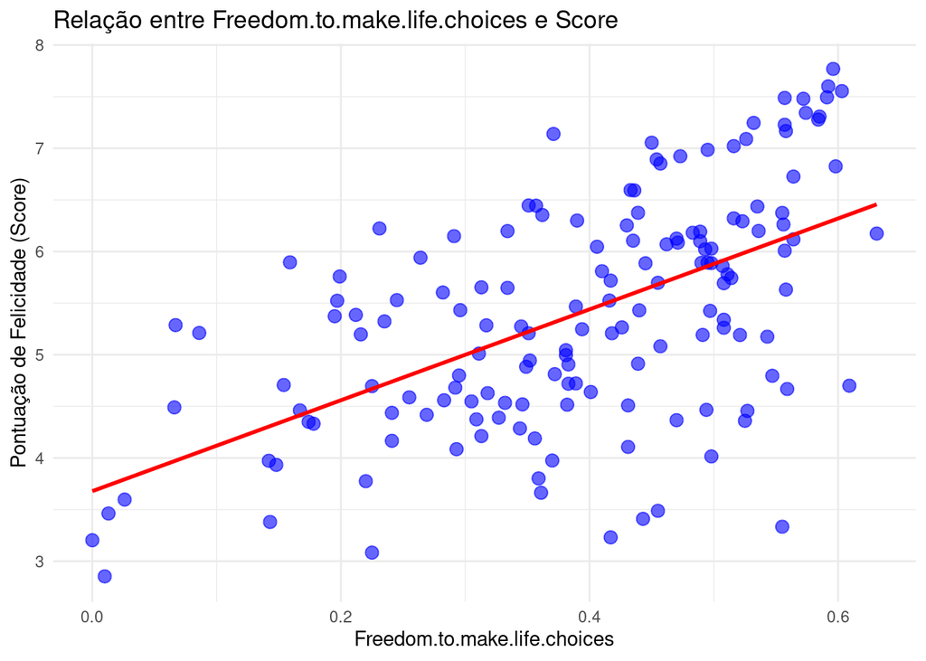

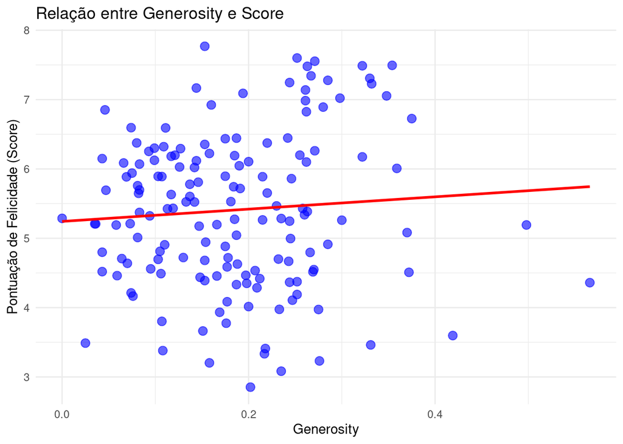

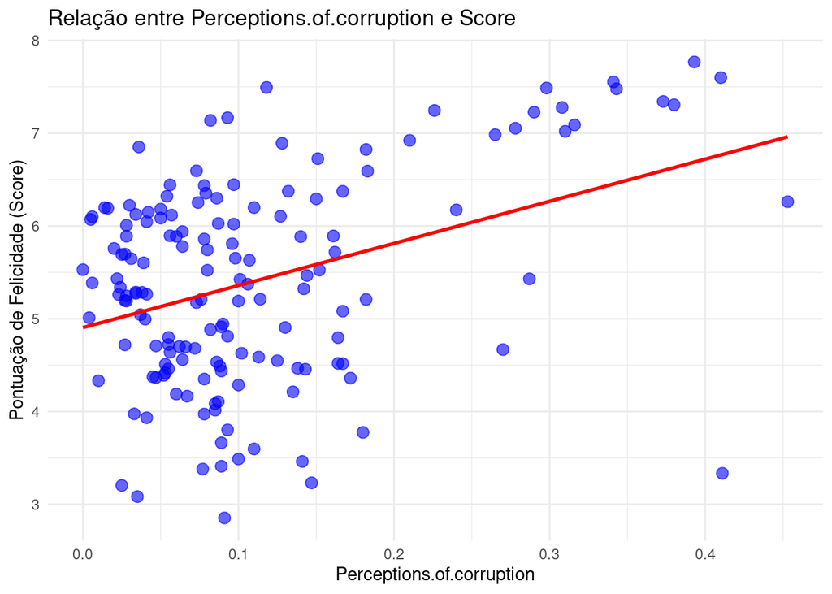

```r
variaveis <- c("GDP.per.capita", "Social.support", "Healthy.life.expectancy",
               "Freedom.to.make.life.choices", "Generosity", "Perceptions.of.corruption")

for (var in variaveis) {
  p <- ggplot(data, aes_string(x = var, y = "Score")) +
    geom_point(color = "blue", alpha = 0.6, size = 3) +
    geom_smooth(method = "lm", se = FALSE, color = "red", linewidth = 1) +
    labs(
      title = paste("Relação entre", var, "e Score"),
      x = var,
      y = "Pontuação de Felicidade (Score)"
    ) +
    theme_minimal()

  print(p)
}
```

## Interpretação dos coeficientes

### Intercepto ($\text{Intercept} = 1.7952$):

- O valor médio de $\text{Score}$ é **1.7952** quando todas as variáveis independentes ($\text{GDP.per.capita}, \text{Social.support}, \dots$) são iguais a zero.
- Embora o intercepto seja estatisticamente significativo ($p < 0.05$), não tem uma interpretação prática relevante, pois valores zero não fazem sentido neste contexto.

### GDP per capita($\beta = 0.7754, p < 0.05$):

- Cada aumento de 1 unidade no $\text{GDP.per.capita}$ está associado a um aumento médio de **0.7754 unidades** em $\text{Score}$, mantendo as outras variáveis constantes.
- É significativo para o modelo ($p < 0.05$), mostrando que a prosperidade econômica é um forte preditor de felicidade.

### Social support($\beta = 1.1242, p < 0.05$):

- Cada aumento de 1 unidade no $\text{Social.support}$ está associado a um aumento médio de **1.1242 unidades** em $\text{Score}$, mantendo as outras variáveis constantes.
- É significativo para o modelo ($p < 0.05$), indicando que o suporte social é uma variável importante para felicidade.

### Healthy life expectancy($\beta = 1.0782, p < 0.05$):

- Cada aumento de 1 unidade na expectativa de vida está associado a um aumento médio de **1.0781 unidades** em $\text{Score}$, mantendo as outras variáveis constantes.
- É significativo para o modelo ($p < 0.05$), mostrando que a saúde impacta fortemente a felicidade.

### Freedom to make life choices($\beta = 1.4548, p < 0.05$):

- Cada aumento de 1 unidade na liberdade para tomar decisões está associado a um aumento médio de **1.4548 unidades** em $\text{Score}$, mantendo as outras variáveis constantes.
- É significativo para o modelo ($p < 0.05$), indicando que a percepção de liberdade é importante na felicidade.

### Generosity($\beta = 0.4898, p = 0.32679$):

- Cada aumento de 1 unidade na generosidade está associado a um aumento médio de **0.4898 unidades** em $\text{Score}$, mantendo as outras variáveis constantes.
- Não significativo ($p > 0.05$).Isso sugere que a generosidade não tem uma contribuição estatisticamente relevante para prever $\text{Score}$ neste modelo.

### Perceptions of corruption($\beta = 0.9723, p = 0.07553$):

- Cada aumento de 1 unidade na percepção de corrupção está associado a um aumento médio de **0.9723 unidades** em $\text{Score}$, mantendo as outras variáveis constantes.
- Não significativo ($p > 0.05$). Embora próximo do limite de significância, o impacto da percepção de corrupção no $\text{Score}$ não é relevante no modelo.

## Interpretação do coeficiente de determinação ($R^2$)

```r
resumo_modelo <- summary(modelo)

r2 <- resumo_modelo$r.squared
cat("O coeficiente de determinação (R²) é:", round(r2, 4), "\n")
```

```
## O coeficiente de determinação (R²) é: 0.7792
```

```r
r2_ajustado <- resumo_modelo$adj.r.squared
cat("O coeficiente de determinação ajustado (R² ajustado) é:", round(r2_ajustado, 4), "\n")
```

```
## O coeficiente de determinação ajustado (R² ajustado) é: 0.7703
```

### Coeficiente de Determinação Ajustado ($R^2 \text{ ajustado} = 0.7703$)

- O $R^2$ ajustado indica que 77,03% da variação total na pontuação de felicidade (Score) é explicada pelas variáveis independentes no modelo de regressão.
- O $R^2$ ajustado leva em conta o número de variáveis independentes no modelo e penaliza a inclusão de variáveis que não contribuem significativamente para explicar a variável resposta.
- Aqui, o $R^2$ ajustado é quase igual o $R^2$, indicando que o modelo é eficiente e as variáveis escolhidas têm relevância, mas algumas podem ter contribuição menor.
- Aqui, o $R^2$ ajustado próximo de 1 significa que o modelo tem um bom ajuste, indicando que o modelo é eficiente e as variáveis escolhidas têm relevância, mas algumas podem ter contribuição menor.

## ANOVA

```r
anova(modelo)
```

```
## Analysis of Variance Table
##
## Response: Score
##                               Df  Sum Sq Mean Sq  F value    Pr(>F)
## GDP.per.capita                 1 121.040 121.040 425.2349 < 2.2e-16 ***
## Social.support                 1  14.108  14.108  49.5625 6.558e-11 ***
## Healthy.life.expectancy        1   4.344   4.344  15.2601 0.0001417 ***
## Freedom.to.make.life.choices   1   8.567   8.567  30.0969 1.722e-07 ***
## Generosity                     1   0.666   0.666   2.3401 0.1281989
## Perceptions.of.corruption      1   0.915   0.915   3.2137 0.0750526 .
## Residuals                    149  42.412   0.285
## ---
## Signif. codes:  0 '***' 0.001 '**' 0.01 '*' 0.05 '.' 0.1 ' ' 1
```

## Multicolinearidade

```r
# Matriz de variância e covariância arredondada
vcov_matrix <- round(vcov(modelo), digits = 6)

# Exibir a matriz de variância e covariância formatada
vcov_matrix %>%
  kable(format = "html", caption = "Matriz de Variância e Covariância") %>%
  kable_styling(bootstrap_options = c("striped", "hover", "condensed"))
```

Matriz de Variância e Covariância

|  | (Intercept) | GDP.per.capita | Social.support | Healthy.life.expectancy | Freedom.to.make.life.choices | Generosity | Perceptions.of.corruption |
| --- | --- | --- | --- | --- | --- | --- | --- |
| (Intercept) | 0.044552 | 0.013234 | -0.028946 | -0.014560 | -0.007298 | -0.037256 | 0.005391 |
| GDP.per.capita | 0.013234 | 0.047622 | -0.020714 | -0.045006 | 0.002025 | 0.015134 | -0.020354 |
| Social.support | -0.028946 | -0.020714 | 0.056122 | -0.018059 | -0.026122 | 0.003116 | 0.023793 |
| Healthy.life.expectancy | -0.014560 | -0.045006 | -0.018059 | 0.111916 | -0.005195 | -0.002971 | -0.013116 |
| Freedom.to.make.life.choices | -0.007298 | 0.002025 | -0.026122 | -0.005195 | 0.140878 | -0.040051 | -0.064111 |
| Generosity | -0.037256 | 0.015134 | 0.003116 | -0.002971 | -0.040051 | 0.247751 | -0.073484 |
| Perceptions.of.corruption | 0.005391 | -0.020354 | 0.023793 | -0.013116 | -0.064111 | -0.073484 | 0.294155 |

```r
# Análise de multicolinearidade (VIF)
vif_values <- vif(modelo)

# Exibir os valores de VIF formatados
vif_values %>%
  kable(format = "html", caption = "Valores de VIF para Diagnóstico de Multicolinearidade") %>%
  kable_styling(bootstrap_options = c("striped", "hover", "condensed"))
```

Valores de VIF para Diagnóstico de Multicolinearidade

|  | x |
| --- | --- |
| GDP.per.capita | 4.115838 |
| Social.support | 2.735651 |
| Healthy.life.expectancy | 3.572728 |
| Freedom.to.make.life.choices | 1.575090 |
| Generosity | 1.224101 |
| Perceptions.of.corruption | 1.431594 |

### Conclusão:

Com os resultados apresentados, evidencia-se que não há multicolinearidade entre as varíáveis: - Nenhuma das variáveis independentes apresentou $\text{VIF} > 10$, o que indica que a multicolinearidade no modelo é **moderada** e aceitável.

## Análise de resíduos:

```r
residuos = residuals(modelo)
```

### Independência:

Nesse caso os dados são espaciais, mas esse fator é desconsiderado para as análises.

### Normalidade:

#### Histograma:

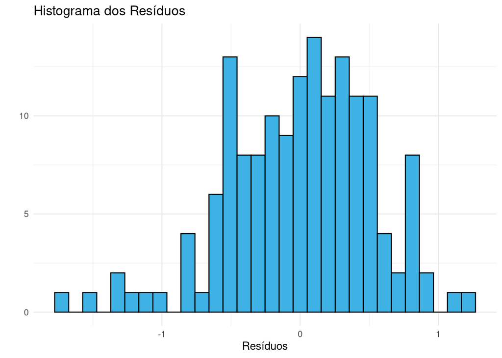

```r
# Histograma dos Resíduos
ggplot(modelo, aes(.resid)) +
  geom_histogram(bins = 30, fill = "#3eb2e4", color = "black") +
  labs(title = "Histograma dos Resíduos",
       x = "Resíduos",
       y = " ") +
  theme_minimal()
```

#### Qqplot:

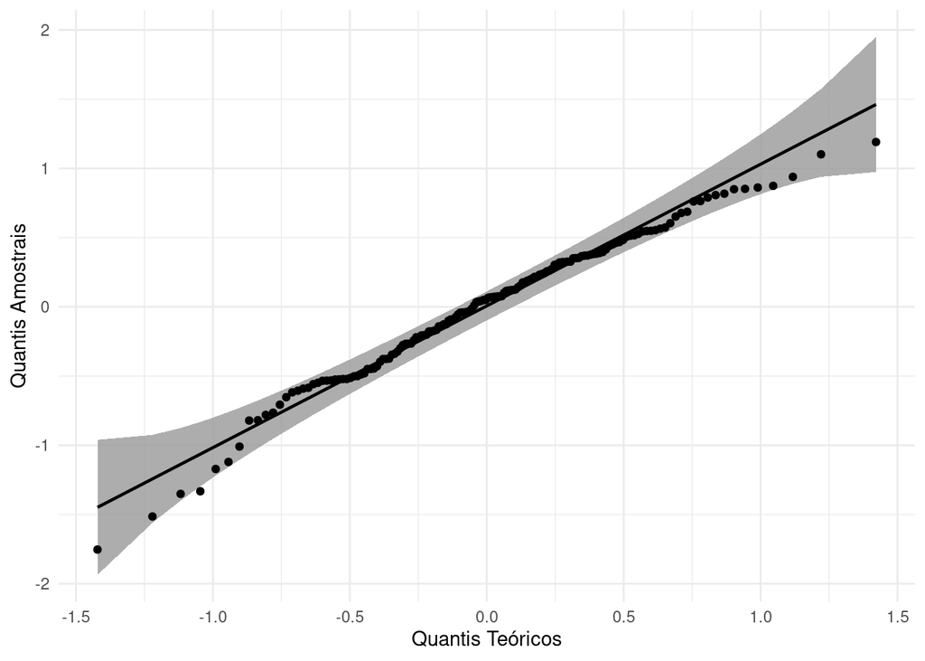

```r
ggplot(data.frame(residuos), mapping = aes(sample = residuos)) +
    stat_qq_band(distribution = "norm") +
    stat_qq_line(distribution = "norm") +
    stat_qq_point(distribution = "norm") +
    labs(x = "Quantis Teóricos", y = "Quantis Amostrais")+
    theme_minimal()
```

#### Teste de Normalidade:

```r
norm.test.stat = c(shapiro.test(modelo$residuals)$statistic,
                   ks.test(modelo$residuals, "pnorm")$statistic)

norm.test.pvalue = c(shapiro.test(modelo$residuals)$p.value,
                   ks.test(modelo$residuals, "pnorm")$p.value)

norm.test = cbind(norm.test.stat, norm.test.pvalue)

rownames(norm.test) = c("Shapiro-Wilk", "Kolmogorov-Smirnov")

colnames(norm.test) = c("Statistic", "P.value")

kable(norm.test, align = "c", caption = "Testes de normalidade")
```

Testes de normalidade

|  | Statistic | P.value |
| --- | --- | --- |
| Shapiro-Wilk | 0.9818012 | 0.0374733 |
| Kolmogorov-Smirnov | 0.1850644 | 0.0000457 |

#### Conclusão:

Através do histograma podemos notar um comportamento não normal dos resíduos.Pelo qqplot, é possível avaliar a não normalidade dos dados, principalmente nas caudas.E os testes de Shapiro-Wilk e Kolmogorov-Smirnov rejeitaram a hipótese nula de que os dados sejam normalmente distribuídos.Logo, os resíduos desse modelo não seguem distribuição normal.

### Homocedasticidade:

#### Gráfico dos Resíduo $\times$ Valores ajustados

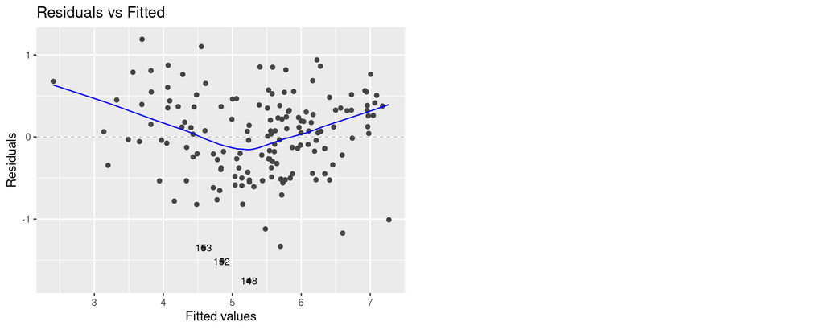

```r
autoplot(modelo, which = 1, label.size = 3)
```

#### Teste Breusch-Pagan:

```r
homo.test = cbind(bptest(modelo, studentize = FALSE)$statistic,
                  bptest(modelo, studentize = FALSE)$p.value)

rownames(homo.test) = c("Breusch-Pagan")
colnames(homo.test) = c("Statistic", "P.value")

kable(homo.test, align = "c", caption = "Teste de homocedasticidade")
```

Teste de homocedasticidade

|  | Statistic | P.value |
| --- | --- | --- |
| Breusch-Pagan | 21.99838 | 0.0012117 |

#### Conclusão:

Pelo gráfico dos resíduo $\times$ valores ajustados, os resíduos parecem se comportar de forma aleatória. Porém, o teste de Breusch-Pagan rejeitou a hipótese nula de homoscedasticidade. Logo os resíduos não apresentam variância constante.

## Outliers, pontos de alavanca e pontos influentes

### Outliers

```r
# Resíduos padronizados
residuos_padronizados <- rstandard(modelo)

# Identificar observações
outliers <- which(abs(residuos_padronizados) > 3)
outliers
```

```
## 148 152
## 148 152
```

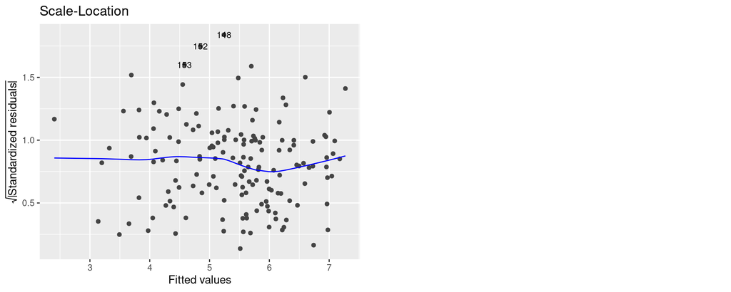

```r
autoplot(modelo, 3, label.size = 3)
```

Com base no código acima, o qual calcula os resíduos padronizados, é possível perceber que há dois outliers, as observações 148 e 152. Essas observações desviam significativamente do padrão esperado do modelo, e nesse caso, são os países Botswana e Rwanda, ambos países da África. Além disso, com base no gráfico, também é possível observar que esses países estão mais afastados da reta de regressão esperada.

### Alavancas

```r
# Calcular leverage
leverage <- hatvalues(modelo)

# Critério para leverage alto
n <- nrow(data)
k <- length(coef(modelo)) - 1
cutoff_leverage <- 2 * (k + 1) / n
cutoff_leverage
```

```
## [1] 0.08974359
```

```r
# Identificar pontos de alavanca
pontos_alavanca <- which(leverage > cutoff_leverage)
pontos_alavanca
```

```
##  34  92 112 131 135 147 149 152 155
##  34  92 112 131 135 147 149 152 155
```

```r
length(pontos_alavanca)
```

```
## [1] 9
```

```r
hat_valores <- hatvalues(modelo)
df <- data.frame(
  obs = seq_along(hat_valores),
  hat = hat_valores
)

limite <- 2 * mean(hat_valores)
limite
```

```
## [1] 0.08974359
```

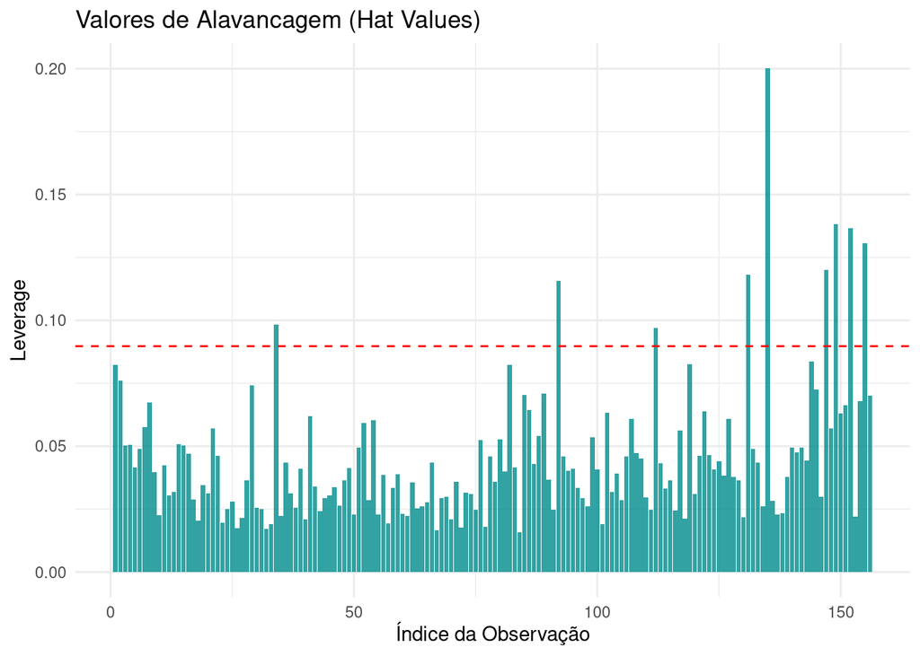

```r
ggplot(df, aes(x = obs, y = hat)) +
  geom_bar(stat = "identity", fill = "darkcyan", alpha = 0.8) +
  geom_hline(yintercept = limite, color = "red", linetype = "dashed") +
  theme_minimal() +
  labs(title = "Valores de Alavancagem (Hat Values)",
       x = "Índice da Observação",
       y = "Leverage")
```

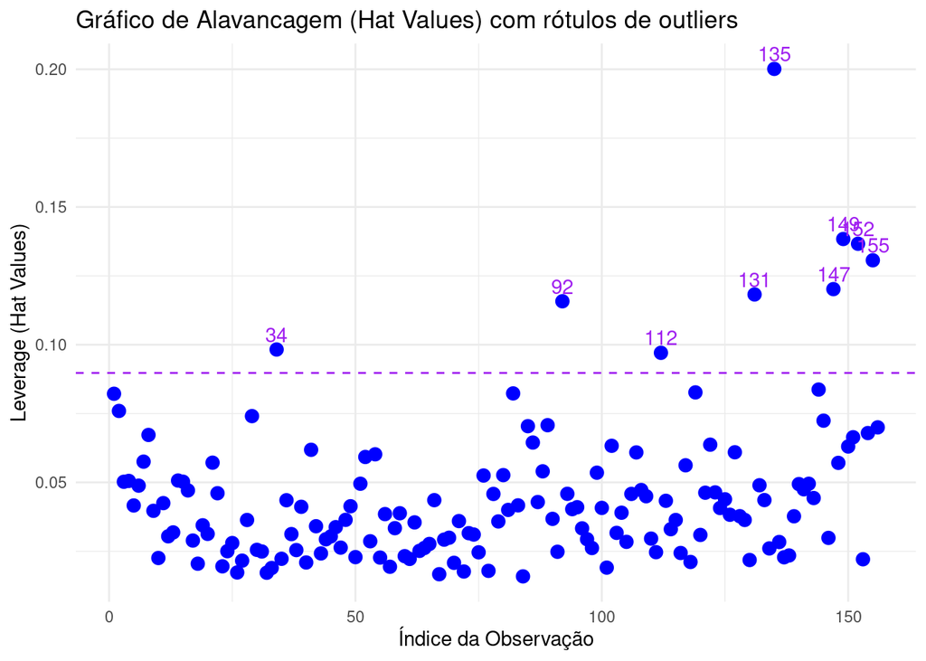

```r
ggplot(df, aes(x = obs, y = hat)) +
  geom_point(size = 3, color = "blue") +
  geom_hline(yintercept = limite, color = "purple", linetype = "dashed") +
  # Adicionando rótulos condicionalmente
  geom_text(
    aes(label = ifelse(hat > limite, obs, "")),  # só mostra obs se hat>limite
    vjust = -0.5,   # ajusta a posição vertical do texto
    color = "purple"
  ) +
  theme_minimal() +
  labs(
    title = "Gráfico de Alavancagem (Hat Values) com rótulos de outliers",
    x = "Índice da Observação",
    y = "Leverage (Hat Values)"
  )
```

É possível perceber que há 9 observações que excedem o limite como indicador de alavancagem, as quais são 34, 92, 112, 131, 135, 147, 149, 152 e 155.

### Pontos influentes

```r
cooks_distance <- cooks.distance(modelo)

length(data$Score)
```

```
## [1] 156
```

```r
# Identificar observações com distância de Cook > 1
which(cooks_distance > 1)
```

```
## named integer(0)
```

```r
which(cooks_distance > 4/length(data$Score))
```

```
##   1  34  76 102 131 148 152 155
##   1  34  76 102 131 148 152 155
```

```r
length(which(cooks_distance > 4/length(data$Score)))
```

```
## [1] 8
```

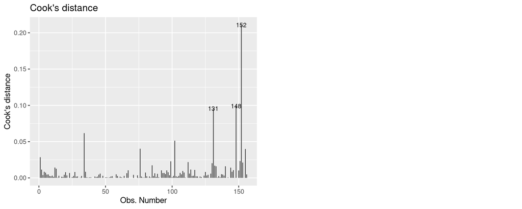

```r
autoplot(modelo, 4, label.size = 3)
```

Logo, com base nos cálculos e no gráfico, há 8 pontos influentes, os quais são as observações 1, 34, 76, 102, 131, 148, 152, 155.

```r
pontos_influentes <- c(1, 34, 76, 102, 131, 148, 152, 155)
length(pontos_influentes)
```

```
## [1] 8
```

```r
dados_influentes <- data[pontos_influentes, c("Country.or.region")]
dados_influentes$ponto <- pontos_influentes
dados_influentes
```

```
## [[1]]
## [1] "Finland"
##
## [[2]]
## [1] "Singapore"
##
## [[3]]
## [1] "Hong Kong"
##
## [[4]]
## [1] "Benin"
##
## [[5]]
## [1] "Myanmar"
##
## [[6]]
## [1] "Botswana"
##
## [[7]]
## [1] "Rwanda"
##
## [[8]]
## [1] "Central African Republic"
##
## $ponto
## [1]   1  34  76 102 131 148 152 155
```

## Transformação

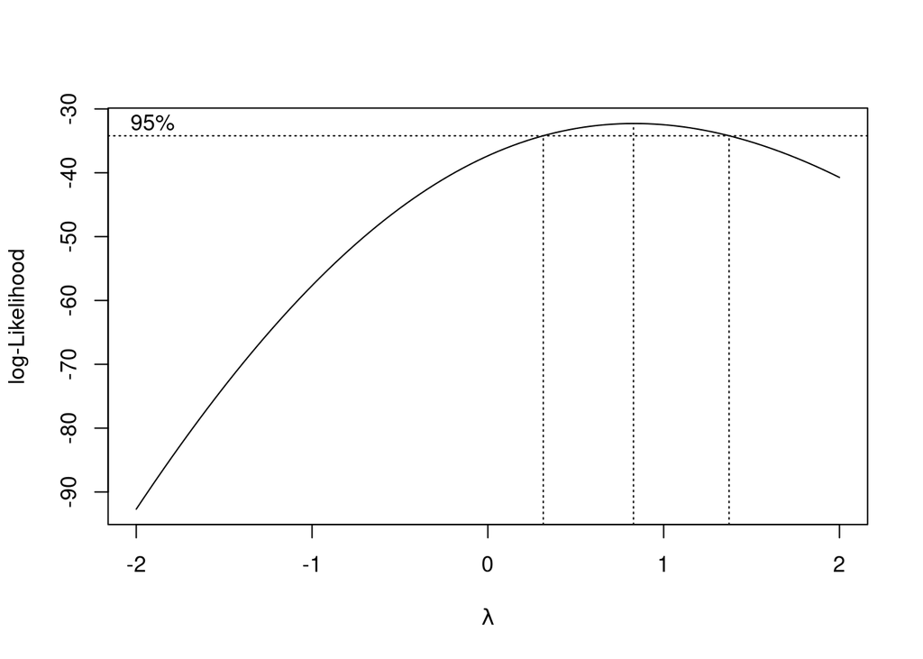

```r
library(MASS)
boxcox(modelo, lambda = seq(-2, 2, by = 0.1))
```

## Conclusão

- Com base nos resultados obtidos, conclui-se que o modelo de regressão linear apresentou um bom ajuste, explicando aproximadamente 77,92% da variação na pontuação de felicidade (Score) dos países analisados. Entre as variáveis explicativas, PIB per capita, suporte social, expectativa de vida e liberdade para tomar decisões destacaram-se como fatores significativos e positivamente associados à felicidade, reforçando a importância de investimentos econômicos e sociais para a melhoria do bem-estar das populações. Por outro lado, generosidade e percepção de corrupção não apresentaram significância estatística no modelo, sugerindo que esses fatores, embora relevantes no contexto geral, não desempenham papel determinante na explicação do Score nesse conjunto de dados. Esses resultados oferecem informções valiosas para governos e formuladores de políticas públicas sobre os principais determinantes da felicidade em diferentes países.